# Composition Analysis of vd16 dated 2026-05-22

# Overall summary

105,638 records and 20,615,267 attribute values in total. Constituent files:

- data/vd16/vd16.parquet (73.9MB)

## Temporal overview

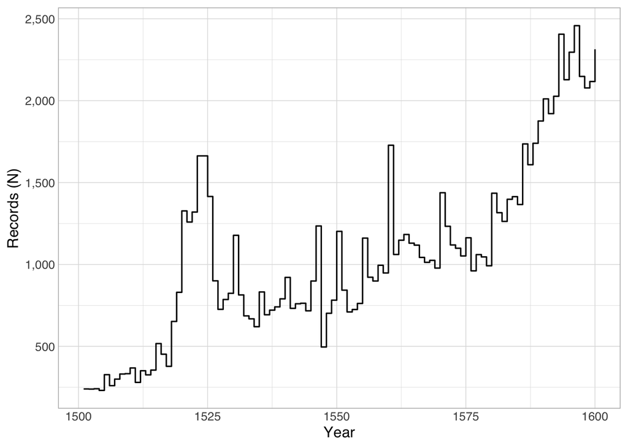

119 records do not have easily parseable dates between the years 1501 and 1600.

## Language overview

| [] | Records (N) | Proportion (%) |
| --- | --- | --- |
| lat (Latin) | 55773 | 0.506465556382921 |
| ger (German) | 48944 | 0.444452516300104 |
| grc (Greek, Ancient (to 1453)) | 2404 | 0.021830333629974 |
| NA | 1003 | 0.00910808012931113 |
| nds (Low German; Low Saxon; German, Low; Saxon, Low) | 800 | 0.00726467009316939 |
| heb (Hebrew) | 387 | 0.00351428415757069 |
| gre (Modern Greek (1453-)) | 208 | 0.00188881422422404 |
| und (Undetermined) | 110 | 0.000998892137810792 |
| fre (French) | 98 | 0.000889922086413251 |
| dut (Dutch; Flemish) | 83 | 0.000753709522166325 |

[output cut: 26 more lines]

# Field code usage overview

In total, 221 distinct fields are used.

Legend for the table below:

- `records`: how many records have at least one of this field
- `r_p`: the above as a percentage of all records
- `n`: the total number of appearances of this field
- `vals_per_rec`: calculated from the above, the mean number of appearances of this field per record
- `recs_with_mult_vals`: the number of records that have more than one repetition of this field

| field_code | field_description | records | r_p | n | vals_per_rec | recs_with_mult_vals |
| --- | --- | --- | --- | --- | --- | --- |
| <a name="001@" href="https://swbtools.bsz-bw.de/cgi-bin/k10plushelp.pl?cmd=kat&val=0000">001@</a> | ILN-bits, supplier code a.o. | 105638 | 1 | 105808 | 1.0016092693917 | 170 |
| <a name="001A" href="https://swbtools.bsz-bw.de/cgi-bin/k10plushelp.pl?cmd=kat&val=0200">001A</a> | Kennung und Datum der Ersterfassung | 105638 | 1 | 105638 | 1 | 0 |
| <a name="001B" href="https://swbtools.bsz-bw.de/cgi-bin/k10plushelp.pl?cmd=kat&val=0210">001B</a> | Kennung und Datum der letzten Änderung | 105638 | 1 | 211276 | 2 | 105638 |
| <a name="001D" href="https://swbtools.bsz-bw.de/cgi-bin/k10plushelp.pl?cmd=kat&val=0230">001D</a> | Kennung und Datum der Statusänderung | 105638 | 1 | 105638 | 1 | 0 |
| <a name="001U" href="https://swbtools.bsz-bw.de/cgi-bin/k10plushelp.pl?cmd=kat&val=000K">001U</a> | Characterset | 105638 | 1 | 105639 | 1.00000946629054 | 1 |
| <a name="001X" href="https://swbtools.bsz-bw.de/cgi-bin/k10plushelp.pl?cmd=kat&val=000A">001X</a> | Owner main record | 105638 | 1 | 105638 | 1 | 0 |
| <a name="002@" href="https://swbtools.bsz-bw.de/cgi-bin/k10plushelp.pl?cmd=kat&val=0500">002@</a> | Bibliografische Gattung und Status | 105638 | 1 | 105638 | 1 | 0 |
| <a name="002C" href="https://swbtools.bsz-bw.de/cgi-bin/k10plushelp.pl?cmd=kat&val=0501">002C</a> | Inhaltstyp | 105620 | 0.999829606770291 | 211424 | 2.00174209430032 | 105620 |
| <a name="002D" href="https://swbtools.bsz-bw.de/cgi-bin/k10plushelp.pl?cmd=kat&val=0502">002D</a> | Medientyp | 105638 | 1 | 211282 | 2.00005679774324 | 105638 |
| <a name="002E" href="https://swbtools.bsz-bw.de/cgi-bin/k10plushelp.pl?cmd=kat&val=0503">002E</a> | Datenträgertyp | 105636 | 0.999981067418921 | 211278 | 2.00005679881858 | 105636 |

[output cut: 211 more lines]

# Field code usage overview by subfield

In total, 1,132 distinct field+subfield combinations are used.

Legend for the table below:

- `records`: how many records have at least one of this field+subfield
- `r_p`: the above as a percentage of all records
- `dist_vals`: the number of different values appearing in this field+subfield
- `e_vals`: at most seven random sample values of this field+subfield
- `n`: the total number of appearances of this field+subfield
- `vals_per_rec`: calculated from the above, the mean number of appearances of this field+subfield per record
- `recs_with_mult_vals`: the number of records that have more than one repetition of this field+subfield

| subfield_code | subfield_description | records | r_p | dist_vals | e_vals | n | vals_per_rec | recs_with_mult_vals |
| --- | --- | --- | --- | --- | --- | --- | --- | --- |
| [001@: ILN-bits, supplier code a.o.](https://swbtools.bsz-bw.de/cgi-bin/k10plushelp.pl?cmd=kat&val=0000) |  |  |  |  |  |  |  |  |
| 001@$0 | ILN-bits, userbits | 105,638 | 100% | 14,667 | 791,2011,2019 (1)\|65,192,2019 (10)\|39,65,192,1005,2019 (1)\|11,31,50,72 (1)\|39,123,278,2019,2505 (1)\|11,39,50,755,807,2006,2011,2019 (1)\|11,39,65,227,379,1005,2019 (1) | 105,638 | 1 | 0 |
| 001@$a | Supplier code | 170 | 0.16% | 1 | U (170) | 170 | 1 | 0 |
| [001A: Kennung und Datum der Ersterfassung](https://swbtools.bsz-bw.de/cgi-bin/k10plushelp.pl?cmd=kat&val=0200) |  |  |  |  |  |  |  |  |
| 001A$0 | Kennung und Datum der Ersterfassung | 105,638 | 100% | 7,245 | 0001:18-06-18 (1)\|S1LB:19-12-14 (2)\|0001:27-05-14 (7)\|KNBSSU:17-09-90 (1)\|0028:20-03-18 (1)\|DDSU:18-03-16 (1)\|0023:28-03-18 (5) | 105,638 | 1 | 0 |
| [001B: Kennung und Datum der letzten Änderung](https://swbtools.bsz-bw.de/cgi-bin/k10plushelp.pl?cmd=kat&val=0210) |  |  |  |  |  |  |  |  |
| 001B$0 | Kennung und Datum | 105,638 | 100% | 2,205 | 1999:08-02-26 (25)\|0003:07-08-25 (3)\|BSZ:27-07-25 (408)\|2026:01-08-25 (6)\|2034:22-09-25 (14)\|1999:15-07-22 (6)\|KALB:10-07-23 (1) | 105,638 | 1 | 0 |
| 001B$t | Uhrzeit | 105,638 | 100% | 29,661 | 14:51:29.000 (1)\|21:52:43.000 (1)\|00:04:55.000 (1)\|09:53:33.000 (42)\|01:19:27.000 (1)\|01:03:55.000 (2)\|00:40:44.000 (1) | 105,638 | 1 | 0 |
| [001D: Kennung und Datum der Statusänderung](https://swbtools.bsz-bw.de/cgi-bin/k10plushelp.pl?cmd=kat&val=0230) |  |  |  |  |  |  |  |  |
| 001D$0 | Kennung und Datum | 105,638 | 100% | 7,090 | KALB:06-04-17 (1)\|0023:10-12-14 (13)\|0001:02-11-17 (3)\|S1LB:24-11-11 (1)\|0033:08-06-11 (1)\|0547:15-03-05 (1)\|FRUB:15-04-14 (1) | 105,638 | 1 | 0 |
| [001U: Characterset](https://swbtools.bsz-bw.de/cgi-bin/k10plushelp.pl?cmd=kat&val=000K) |  |  |  |  |  |  |  |  |
| 001U$0 | Unicode-Kennzeichen | 105,638 | 100% | 1 | utf8 (105,639) | 105,639 | 1 | 1 |
| [001X: Owner main record](https://swbtools.bsz-bw.de/cgi-bin/k10plushelp.pl?cmd=kat&val=000A) |  |  |  |  |  |  |  |  |
| 001X$0 | Owner | 105,638 | 100% | 1 | 0 (105,638) | 105,638 | 1 | 0 |
| [002@: Bibliografische Gattung und Status](https://swbtools.bsz-bw.de/cgi-bin/k10plushelp.pl?cmd=kat&val=0500) |  |  |  |  |  |  |  |  |
| 002@$0 | Bibliografische Gattung und Status | 105,638 | 100% | 44 | Oav (22,233)\|Eau (151)\|Aax (1)\|Asu (71)\|Ocus (1)\|Ofy (5)\|Afn (72) | 105,638 | 1 | 0 |
| [002C: Inhaltstyp](https://swbtools.bsz-bw.de/cgi-bin/k10plushelp.pl?cmd=kat&val=0501) |  |  |  |  |  |  |  |  |
| 002C$a | Inhaltstyp in ausgeschriebener Form | 105,620 | 99.98% | 5 | Text (105,609)\|Computerdaten (3)\|unbewegtes Bild (71)\|kartografisches Bild (8)\|Noten (21) | 105,712 | 1 | 92 |
| 002C$b | Inhaltstyp in codierter Form | 105,620 | 99.98% | 5 | cri (8)\|sti (71)\|ntm (21)\|txt (105,609)\|cod (3) | 105,712 | 1 | 92 |
| [002D: Medientyp](https://swbtools.bsz-bw.de/cgi-bin/k10plushelp.pl?cmd=kat&val=0502) |  |  |  |  |  |  |  |  |
| 002D$a | Medientyp in ausgeschriebener Form | 105,638 | 100% | 3 | ohne Hilfsmittel zu benutzen (67,542)\|Mikroform (164)\|Computermedien (37,935) | 105,641 | 1 | 3 |
| 002D$b | Medientyp in codierter Form | 105,638 | 100% | 3 | h (164)\|n (67,542)\|c (37,935) | 105,641 | 1 | 3 |
| [002E: Datenträgertyp](https://swbtools.bsz-bw.de/cgi-bin/k10plushelp.pl?cmd=kat&val=0503) |  |  |  |  |  |  |  |  |
| 002E$a | Datenträgertyp in ausgeschriebener Form | 105,636 | 100% | 7 | Online-Ressource (37,935)\|Blatt (1)\|Mikrofilmrolle (6)\|Band (67,539)\|Mikrofilmspule (34)\|Mikrofiche (123)\|Sonstige Mikroformen (1) | 105,639 | 1 | 3 |
| 002E$b | Datenträgertyp in codierter Form | 105,636 | 100% | 7 | cr (37,935)\|nb (1)\|nc (67,539)\|hd (34)\|hj (6)\|hz (1)\|he (123) | 105,639 | 1 | 3 |
| [003@: Pica-Produktionsnummer](https://swbtools.bsz-bw.de/cgi-bin/k10plushelp.pl?cmd=kat&val=0100) |  |  |  |  |  |  |  |  |
| 003@$0 | Pica-Produktionsnummer | 105,638 | 100% | 105,638 | 1922820520 (1)\|567285693 (1)\|745495729 (1)\|567643379 (1)\|1665885459 (1)\|150595298 (1)\|151730962 (1) | 105,638 | 1 | 0 |
| [003D: PPN des umgelenkten GBV- bzw. K10plus-Satzes](https://swbtools.bsz-bw.de/cgi-bin/k10plushelp.pl?cmd=kat&val=2119) |  |  |  |  |  |  |  |  |
| 003D$0 | PPN | 1,383 | 1.31% | 1,426 | 151659753 (1)\|450092119 (1)\|791783669 (1)\|150374933 (1)\|189492627 (1)\|412150204 (1)\|150592647 (1) | 1,432 | 1.04 | 41 |
| [003H: hebis-Pica-Produktionsnummer](https://swbtools.bsz-bw.de/cgi-bin/k10plushelp.pl?cmd=kat&val=0120) |  |  |  |  |  |  |  |  |

[output cut: 1323 more lines]